# 第19章 ggplot2绘图

武汉大学经济与管理学院  
刘开军 博士  
Email: kjliu@whu.edu.cn

## ggplot2

R有四套完整的绘图系统：base、lattice、grid和ggplot2，这些绘图系统各有特点。ggplot2由于其非富的功能、强大的表现力，近年逐渐流行起来。

ggplot2的优点：

- 统一的绘图语言；
- 数据与图形相分离；
- 丰富的图形功能；
- 可绘制复杂、定制的图形；
- ……

首先要下载安装ggplot2包。

```r
install.packages("ggplot2")
library(ggplot2)
```

在ggplot2中，图是用加号将多个函数串联起来而创建，每个函数负责修改属于自己的一部分。一般方法是：

`ggplot() + geom_*()` + 分面函数 + 修饰函数

其中：

- `ggplot()`用于指定绘图时用到的数据；
- `geom_*()`这类函数被称为几何函数，例如：`geom_point()`、`geom_bar()`、`geom_boxplot()`等，用于绘制图形。可以出现多个几何函数；
- 分面函数用于将图形组成图形矩阵，是可选的；
- 修饰函数用于修改图形的标题、坐标轴、图例等，是可选的。

例如：

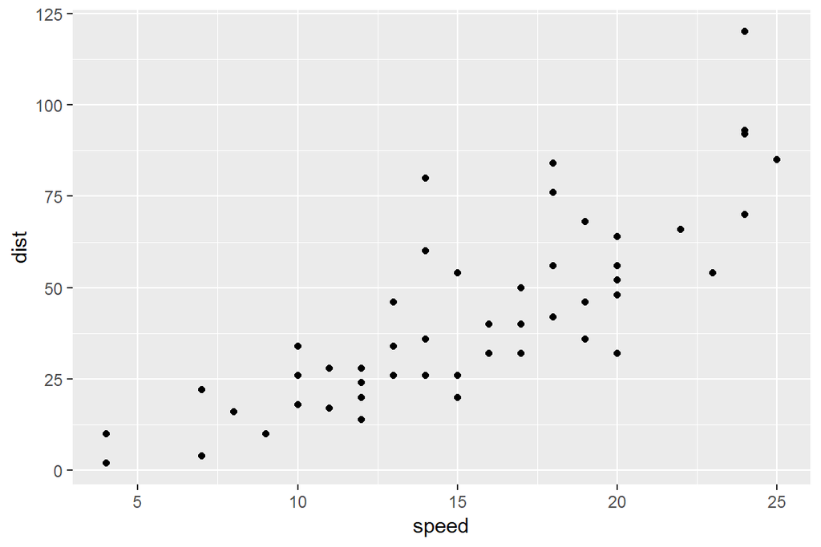

```r
library(ggplot2)
ggplot(data=cars, mapping=aes(x=speed, y=dist)) + geom_point()
```

## ggplot()函数

ggplot()函数用于指定绘图时使用的数据。ggplot2包的原则之一是分离数据与图形，将数据都放在ggplot()函数中，将图形放在几何函数中，尽量将绘图时用到的数据放在ggplot()中。

ggplot()的一般用法是：

ggplot(data=mydata, mapping=aes(x=varX, y=varY,…))

其中，data参数用于指定绘图时使用的数据框，aes用于指定横纵、纵轴等使用的变量。aes()内的参数与几何函数相配合，对不同的几何函数，aes()内的参数有所不同。

## 几何函数

几何函数用于绘制图形。常用的几何函数包括：

| 函数 | 功能 | 常用参数 |
| --- | --- | --- |
| geom_bar() | 条形图 | color, fill, alpha |
| geom_boxplot() | 箱型图 | color, fill, alpha, notch, width |
| geom_density() | 密度图 | color, fill, alpha, linetype |
| geom_freqpoly() | 频率折线图 | color, linetype, size, bins, binwidth |
| geom_histogram() | 直方图 | color, fill, alpha, linetype, bins, binwidth |
| goem_hline() | 水平线 | color, alpha, linetype, size |
| goem_jitter() | 抖动点 | color, size, alpha, shape |
| geom_line() | 线图 | color, alpha, linetype, size |
| geom_point() | 散点图 | color, alpha, shape, size |
| geom_rug() | 地毯图 | color, side |
| geom_smooth() | 拟合曲线 | method, formula, color, fill, linetype, size |
| geom_text() | 文本 | color, alpha, fontface, family, lineheight, size, vjust |
| geom_voilin() | 小提琴图 | color, fill, alpha, linetype |
| geom_vline | 垂直线 | color, alhpa, linetype, size |

几何函数的数据来源于ggplot()的aes()，不同的图形需要的数据不同，因此对应的aes的写法也不同。下面讲解最常用的几何函数：

- geom_point()
- geom_line()
- geom_bar()
- geom_histogram()
- geom_freqpoly()
- geom_boxplot()
- geom_smooth()
- geom_density()
- geom_count()
- geom_tile()

**geom_point()**

用于绘制点图，可以在geom_point()中指定点的符号(shape)、颜色(color)、尺寸(size)等。shape参数的取值与plot()函数中pch参数的取值相同。

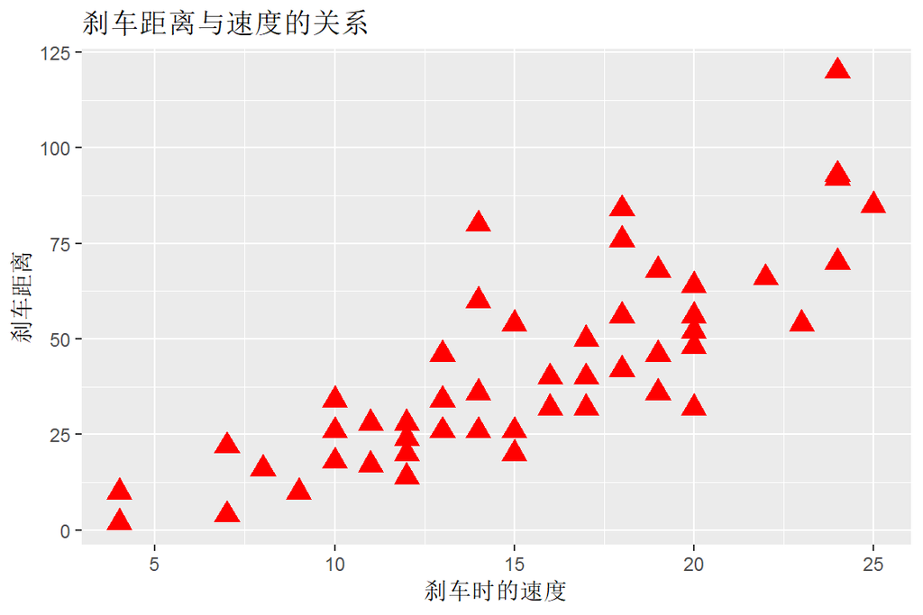

```r
ggplot(data=cars, mapping=aes(x=speed, y=dist)) +
  geom_point(shape=17, color="red", size=4) +
  labs(title="刹车距离与速度的关系", x="刹车时的速度", y="刹车距离")
```

DIY: 如果绘图数据中含有NA值，那么geom_point()会忽略这些点，同时会给出一条Warning信息。如果不想看到这条Warning，可以使用`geom_point(..., na.rm=TRUE)`。

**geom_line()**

用于绘制线图。geom_line()可选参数：color(线的颜色)、linetype(线型)、size(线的粗细)。

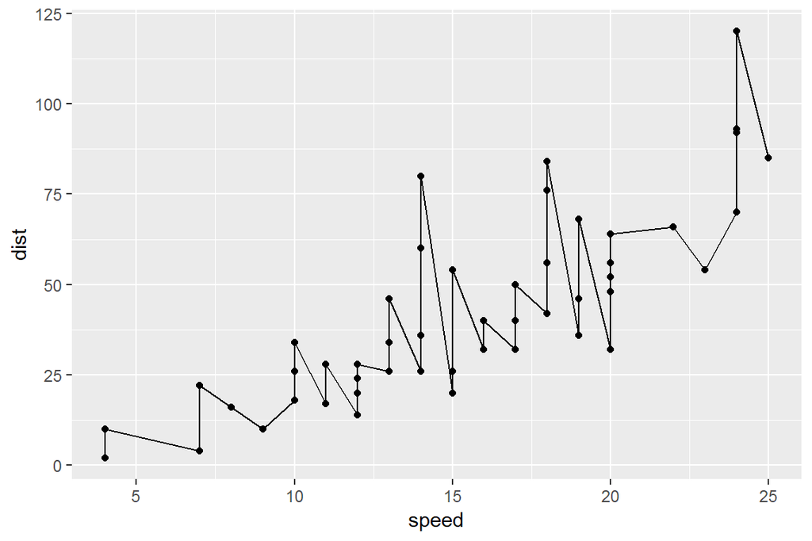

```r
ggplot(data=cars, mapping=aes(x=speed, y=dist))+geom_point()+geom_line()
```

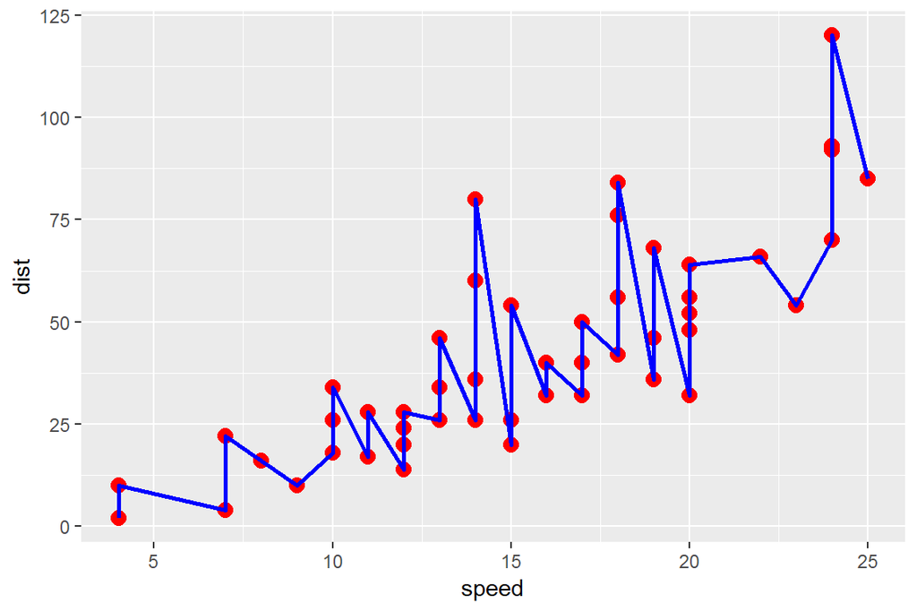

```r
ggplot(data=cars, mapping=aes(x=speed, y=dist)) +
  geom_point(shape=20, size=5, color="red") +
  geom_line(linetype=1, size=1, color="blue")
```

**geom_bar()**

用于绘制条形图。geom_bar()只需要指定横轴变量(必须是一个factor，即离散型变量)，纵轴的值会根据横轴变量的值统计出来，不需要指定纵轴变量，因此在ggplot()中，aes只需要指定x参数。

`geom_bar()`的常用参数：

| 参数 | 说明 |
| --- | --- |
| width | 表示每个条形的宽度，标准宽度为1； |
| color | 表示每个条形的外边框颜色； |
| fill, alpha | 表示每个条形内的填充色和色彩饱和度；alpha=0表示完全透明，alpha=1表示完全实色； |
| weight, stat | 改变统计方式 |

默认情况下，垂直绘制条形，但可以用coord_flip()将条形调整成水平的。

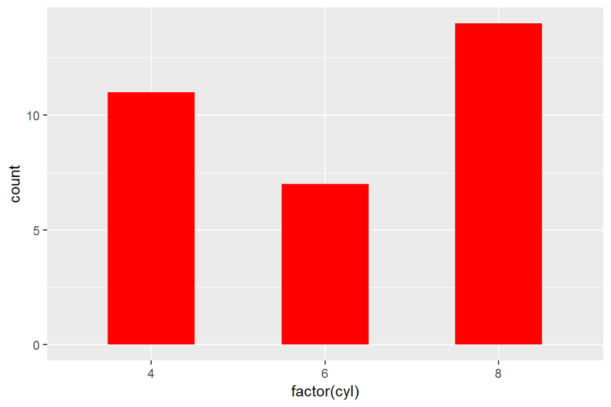

```r
ggplot(data=mtcars, mapping=aes(x=factor(cyl))) + geom_bar(width=0.5, fill="red")
```

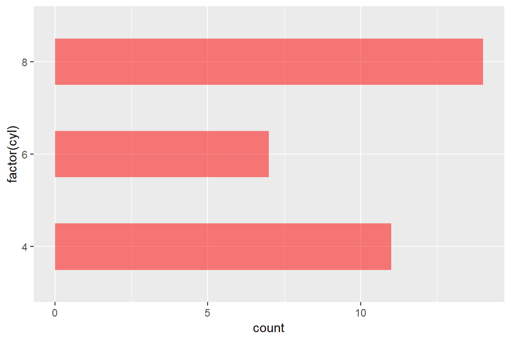

```r
ggplot(data=mtcars, mapping=aes(x=factor(cyl))) +
  geom_bar(width=0.5, fill="red", alpha=0.5) +
  coord_flip()
```

参数stat

默认情况下，`stat`的值为`'count'`，此时`geom_bar()`会统计每个组的行数，作为各条形的高度。若设置`stat="identity"`，并在`aes()`中指定一个y值，那么将会统计各组y值的和，作为各条形的高度。

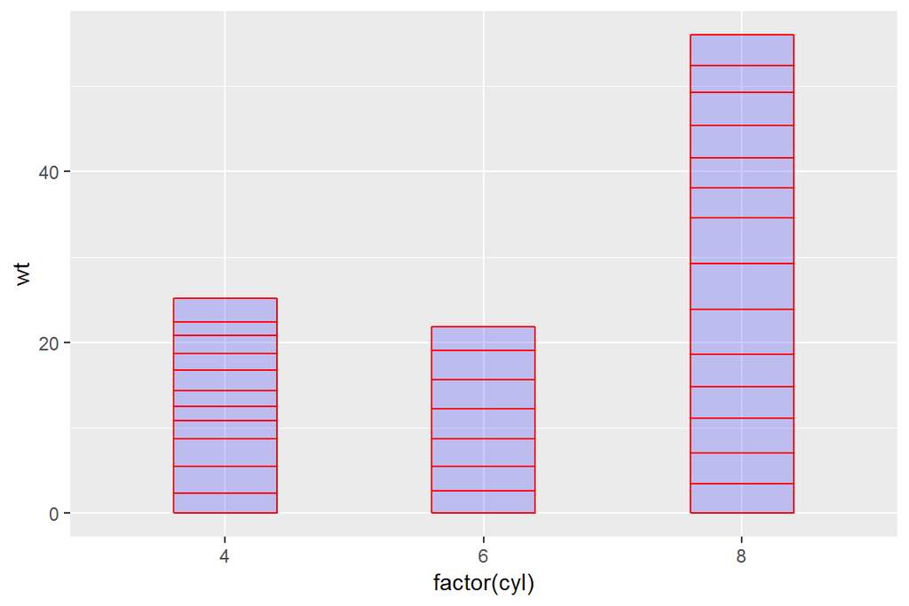

```r
#显示每种发动机的车重
ggplot(data=mtcars, mapping=aes(x=factor(cyl), y=wt))+
  geom_bar(stat="identity", width=0.4, color="red", fill="blue", alpha=0.2)
```

可以看到，每个条形是由多个小格堆叠而成，每个小格的高度由y值决定，条形的总高度是由y的和决定。

借助stat=“identity”，可以直接把统计好的数据绘制成条形图。例如，

```r
a <- c("China", "USA", "British", "German")
b <- c(35, 40, 28, 30)
mydata <- data.frame(country=a, score=b)
mydata
```

```
##   country score
## 1   China    35
## 2     USA    40
## 3 British    28
## 4  German    30
```

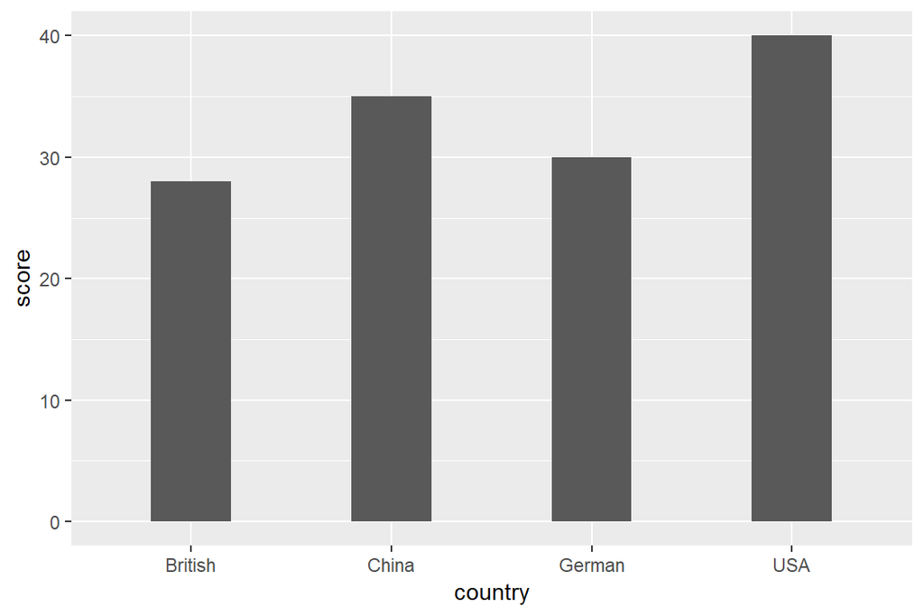

```r
ggplot(data=mydata, mapping=aes(x=country, y=score))+geom_bar(stat="identity", width=0.4)
```

DIY: 如何调整横坐标上各条形的顺序?

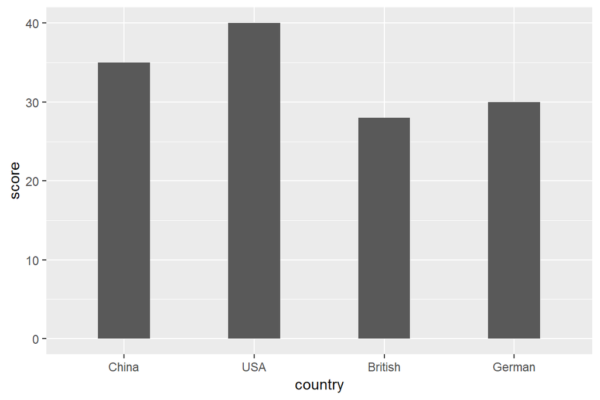

```r
a <- c("China", "USA", "British", "German")
a <- factor(a, levels=c("China", "USA", "British", "German"))   #指定各水平值的顺序
b <- c(35, 40, 28, 30)
mydata <- data.frame(country=a, score=b)

ggplot(data=mydata, mapping=aes(x=country, y=score))+geom_bar(stat="identity", width=0.4)
```

参数weight

在绘制直方图时，默认情况是各条形的高度等于每组的行数。参数weight表示每一行的权值，如果为weight赋值，那么各条形的高度将等于每组中各行的权值之和。

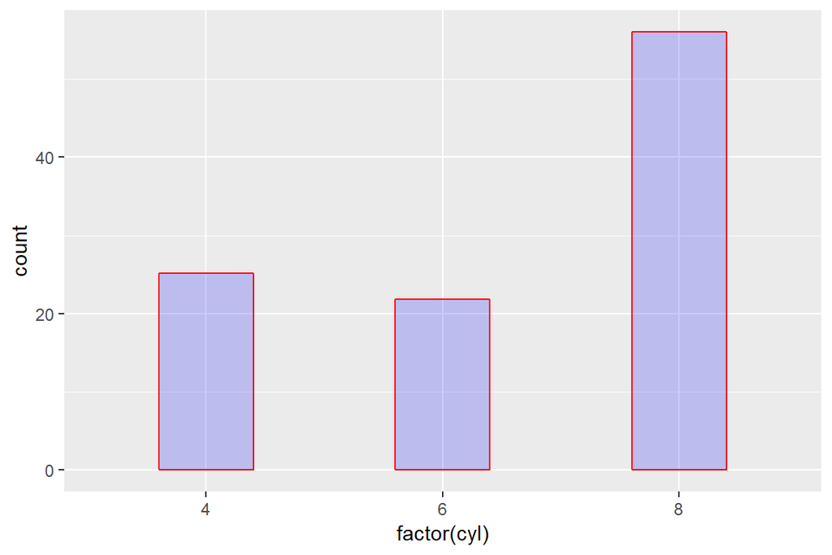

```r
#借助参数weight，实现与stat="identity"相同的功能
#下图与前一页的图相同
ggplot(data=mtcars, mapping=aes(x=factor(cyl), weight=wt))+
  geom_bar(width=0.4, color="red", fill="blue", alpha=0.2)
```

```r
#ggplots2::diamonds记录了53940颗钻石的信息
#diamonds$cut表示钻石的切割质量，diamonds$carat表示钻石重量
str(diamonds)
```

```
## Classes 'tbl_df', 'tbl' and 'data.frame':    53940 obs. of  10 variables:
##  $ carat  : num  0.23 0.21 0.23 0.29 0.31 0.24 0.24 0.26 0.22 0.23 ...
##  $ cut    : Ord.factor w/ 5 levels "Fair"<"Good"<..: 5 4 2 4 2 3 3 3 1 3 ...
##  $ color  : Ord.factor w/ 7 levels "D"<"E"<"F"<"G"<..: 2 2 2 6 7 7 6 5 2 5 ...
##  $ clarity: Ord.factor w/ 8 levels "I1"<"SI2"<"SI1"<..: 2 3 5 4 2 6 7 3 4 5 ...
##  $ depth  : num  61.5 59.8 56.9 62.4 63.3 62.8 62.3 61.9 65.1 59.4 ...
##  $ table  : num  55 61 65 58 58 57 57 55 61 61 ...
##  $ price  : int  326 326 327 334 335 336 336 337 337 338 ...
##  $ x      : num  3.95 3.89 4.05 4.2 4.34 3.94 3.95 4.07 3.87 4 ...
##  $ y      : num  3.98 3.84 4.07 4.23 4.35 3.96 3.98 4.11 3.78 4.05 ...
##  $ z      : num  2.43 2.31 2.31 2.63 2.75 2.48 2.47 2.53 2.49 2.39 ...
```

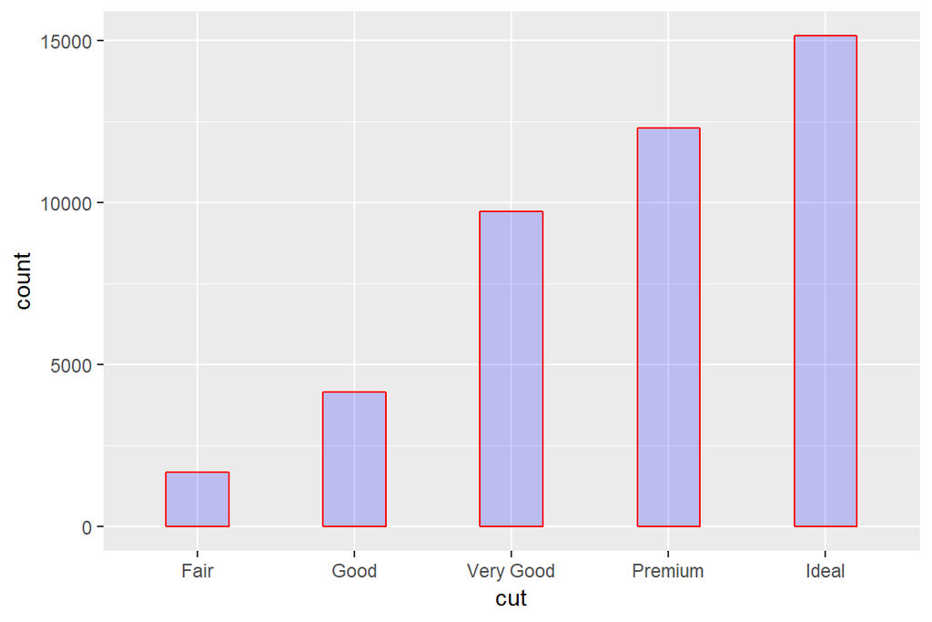

```r
#按照钻石的切割质量进行分类，统计每类钻石的总重量
ggplot(data=diamonds, mapping=aes(x=cut, weight=carat))+
  geom_bar(width=0.4, color="red", fill="blue", alpha=0.2)
```

参数weight与stat的功能有相似之处，不同在于：stat可将每个条形分成多个小格，而weight的每个条形都是一个整体。stat的功能更强。

横轴上条形的顺序

横轴表示的变量是一个factor，默认情况下，各个条形按照因子水平值从小到大排列。我们可以用函数`reorder()`改变横轴上各条形的顺序。

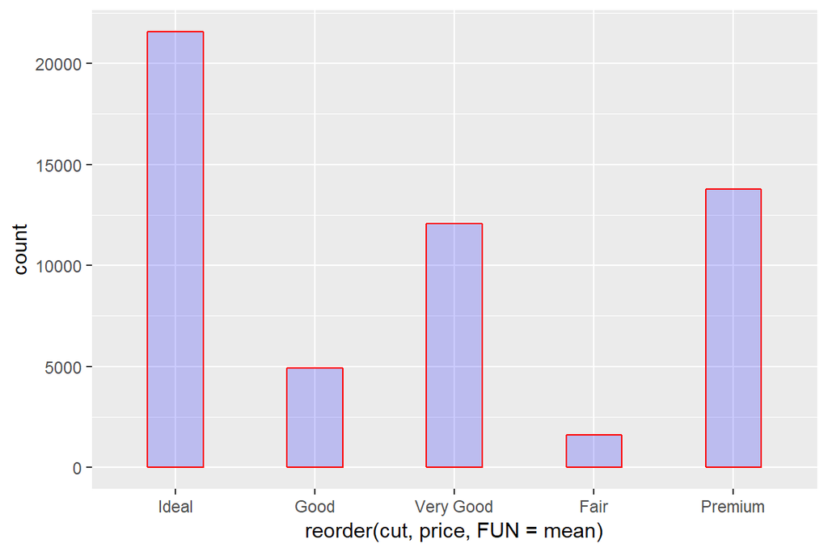

```r
#按照钻石的切割质量进行分类，统计每类钻石的平均价格
aggregate(diamonds["price"], by=list(cut=diamonds$cut), FUN=mean)
##         cut    price
## 1      Fair 4358.758
## 2      Good 3928.864
## 3 Very Good 3981.760
## 4   Premium 4584.258
## 5     Ideal 3457.542

#统计每类钻石的数量，要求各条形按照每类钻石的平均价格顺序排列
ggplot(data=diamonds, mapping=aes(x=reorder(cut, price, FUN=mean))) +
  geom_bar(width=0.4, color="red", fill="blue", alpha=0.2)
```

DIY：函数`reorder()`适用于所有横轴是离散变量的图形，包括`geom_bar(), geom_histogram(), geom_boxplot()`等。

**geom_histogram()**

用于绘制直方图。geom_histogram()只需要指定横轴变量()，纵轴的值会根据横轴变量的值统计出来，不需要指定纵轴变量，因此在ggplot()中，aes只需要指定x参数。

`geom_histogram()`的功能强于`geom_bar()`，可使用factor（离散型变量）或numeric（连续型变量）作为其横坐标。

`geom_histogram()`常用参数有：color, fill, alpha, weight, stat, bins, binwidth等。

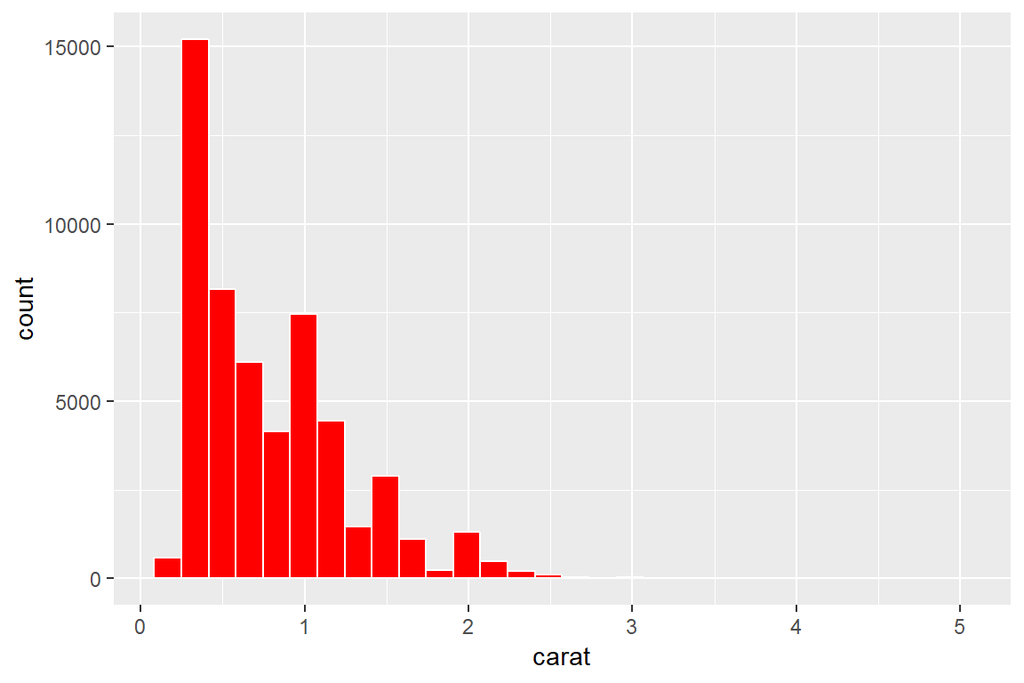

```r
#连续变量的直方图
ggplot(data=diamonds, mapping=aes(x=carat))+geom_histogram(color="white", fill="red")
```

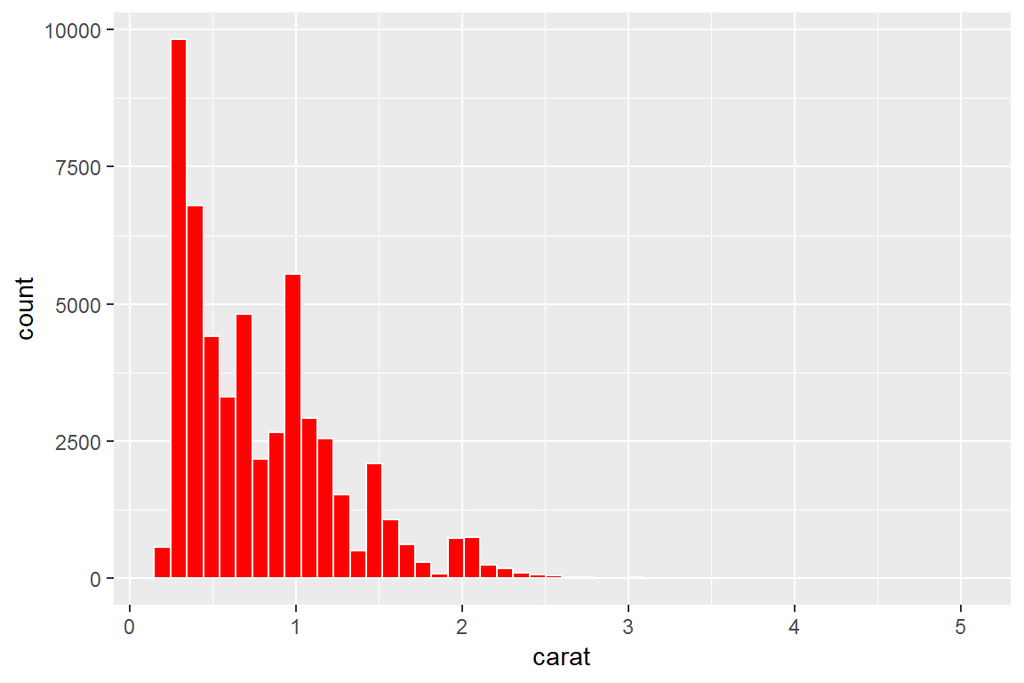

```r
#将统计区间划分得更细，可使用参数bins或binwidth
#参数bins或binwidth只对连续变量有效。对离散变量，每个x值作为一个条形，不需要划分统计区间
ggplot(data=diamonds, mapping=aes(x=carat))+
  geom_histogram(color="white", fill="red", bins=50)  #将x轴划分为50个小区间
```

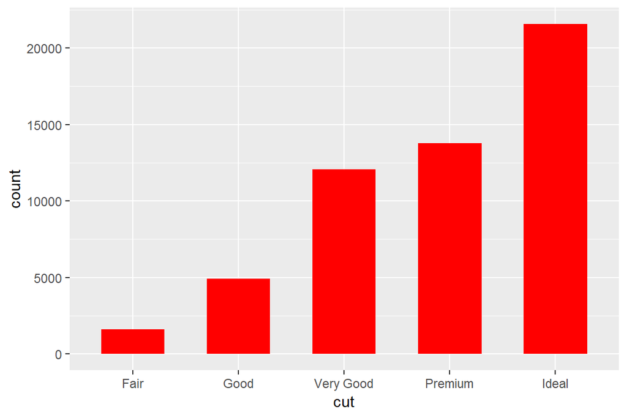

```r
#离散变量的直方图
#下面的语句等价于 ggplot(data=diamonds, mapping=aes(x=cut))+geom_bar(width=0.6, fill="red")
ggplot(data=diamonds, mapping=aes(x=cut))+geom_histogram(stat="count", width=0.6, fill="red")
```

`geom_histogram()`既可以绘制离散变量（即factor）的直方图，也可以绘制连续变量（即numeric vector）的直方图。这两种直方图的绘制方法略有不同。

对于**离散变量**的直方图，geom_histogram()与geom_bar()功能基本相同，只是需要注意，在调用geom_histogram()时需要使用参数`stat="count"`。并且，geom_histogram()与geom_bar()都可以用参数stat和weight来控制纵坐标，用法相同，不再赘述。

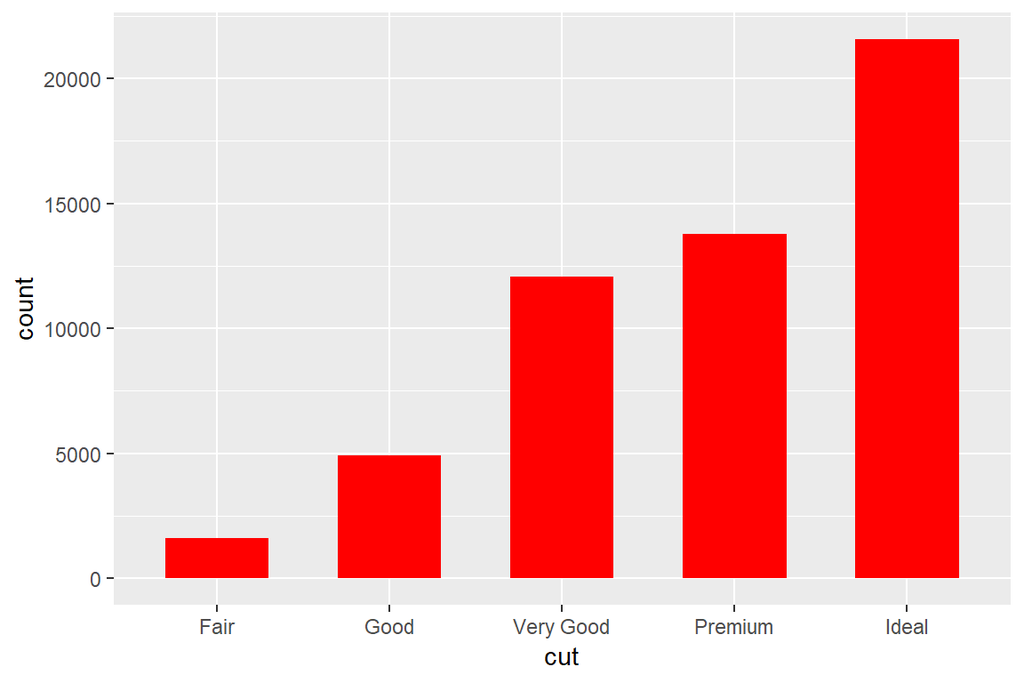

```r
#离散变量的直方图
#下面的语句等价于 ggplot(data=diamonds, mapping=aes(x=cut))+geom_bar(width=0.6, fill="red")
ggplot(data=diamonds, mapping=aes(x=cut))+geom_histogram(stat="count", width=0.6, fill="red")
```

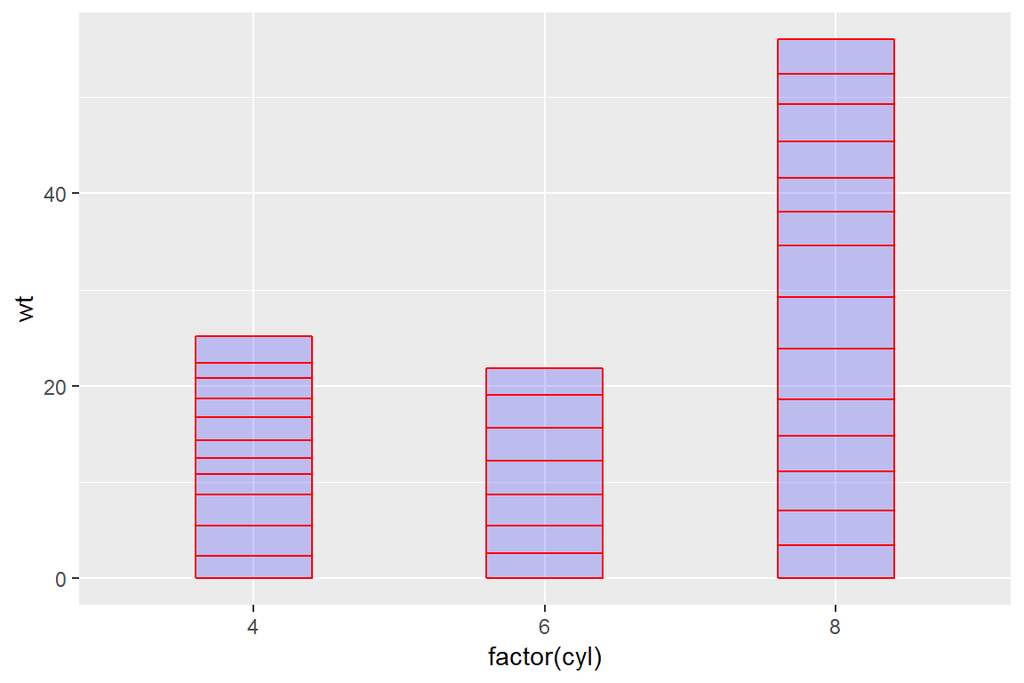

```r
#下面的语句等价于ggplot(data=mtcars, mapping=aes(x=factor(cyl), y=wt))+
#     geom_bar(stat="identity", width=0.4, color="red", fill="blue", alpha=0.2)
ggplot(data=mtcars, mapping=aes(x=factor(cyl), y=wt))+
  geom_histogram(stat="identity", width=0.4, color="red", fill="blue", alpha=0.2)
```

对于**连续变量**的直方图，geom_histogram()会将变量的值分成若干小组，默认情况下，会使用每个小组内的点数作为该小组条形的高度。实际上，geom_histogram()函数在分组统计时，对每个小组会产生四个统计量：

- count：表示每个小组内的点数
- density：表示每个小组的概率密度。这是将所有的条形都进行同比例的缩放，使得所有条形的总面积为1
- ncount：表示每个小组内点数的相对比例。这是将点数最多的小组记为1，其他小组根据本组的点数计算出比例
- ndensity：表示小组的相对频率，最大值为1。这是将概率密度最高的小组记为1，其他小组根据本组的概率密度计算出比例。实际上与ncount计算值相同。

在绘制直方图时，可以使用这些统计量作为纵坐标（即条形的高度）。为与数据源中的变量相区别，这四个统计量的名字前后要加上两个点。

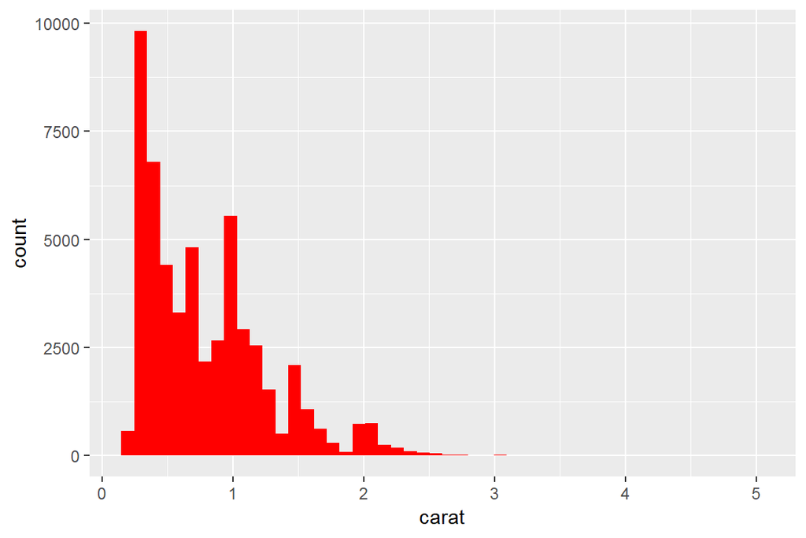

```r
#默认情况下，每个条形的高度表示小组内的点数
ggplot(data=diamonds, mapping=aes(x=carat))+
  geom_histogram(fill="red", bins=50)
```

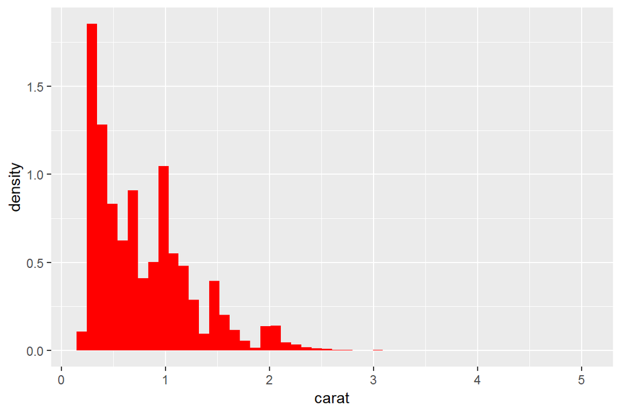

```r
#绘制概率密度图
ggplot(data=diamonds, mapping=aes(x=carat, y=..density..))+
  geom_histogram(fill="red", bins=50)
```

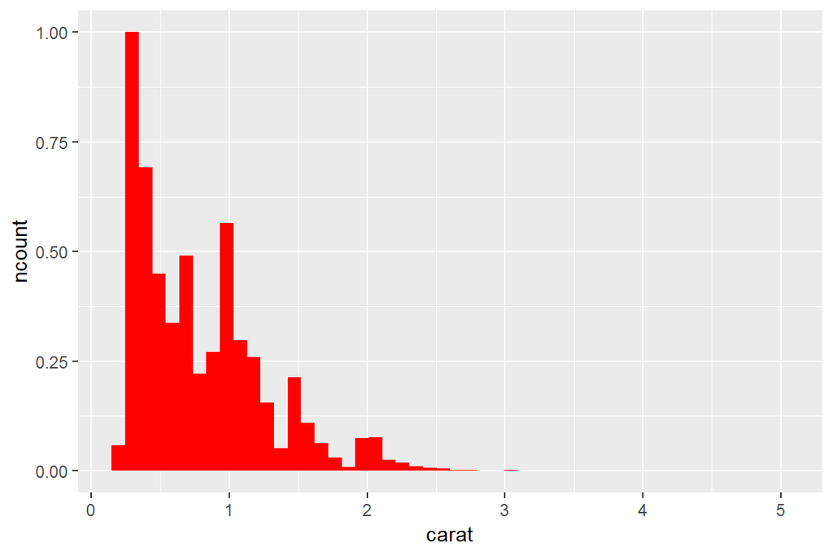

```r
#绘制相对比例比例图
ggplot(data=diamonds, mapping=aes(x=carat, y=..ncount..))+
  geom_histogram(fill="red", bins=50)
```

DIY: `ggplot2::cut_width()`和`dplyr::count()`可帮助我们计算每个小组内点的数量。

```r
library(dplyr)
diamonds %>% count(cut_width(carat, 0.5))
```

```
## # A tibble: 11 x 2
##    `cut_width(carat, 0.5)`     n
##    <fct>                   <int>
##  1 [-0.25,0.25]              785
##  2 (0.25,0.75]             29498
##  3 (0.75,1.25]             15977
##  4 (1.25,1.75]              5313
##  5 (1.75,2.25]              2002
##  6 (2.25,2.75]               322
##  7 (2.75,3.25]                32
##  8 (3.25,3.75]                 5
##  9 (3.75,4.25]                 4
## 10 (4.25,4.75]                 1
## 11 (4.75,5.25]                 1
```

**geom_freqpoly()**

geom_freqpoly()与geom_histogram()功能相同，只是前者不绘制条形，而是使用折线。

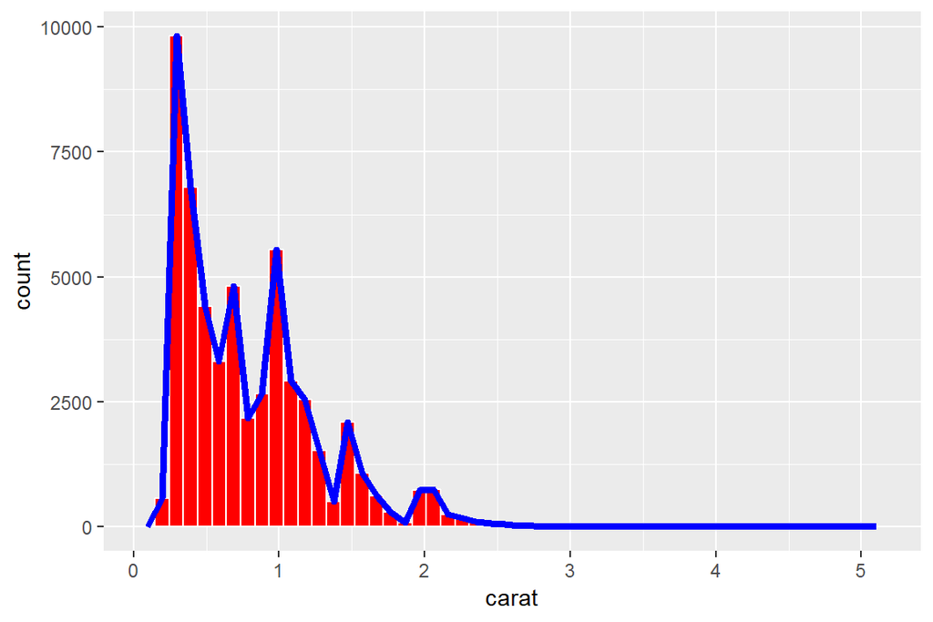

```r
ggplot(data=diamonds, mapping=aes(x=carat))+
  geom_histogram(color="white", fill="red", bins=50)+
  geom_freqpoly(color="blue", size=1.5, bins=50)
```

**geom_boxplot()**

用于绘制箱型图。geom_boxplot()同时需要横坐标变量和纵坐标变量，其中横坐标变量应当是一个factor。

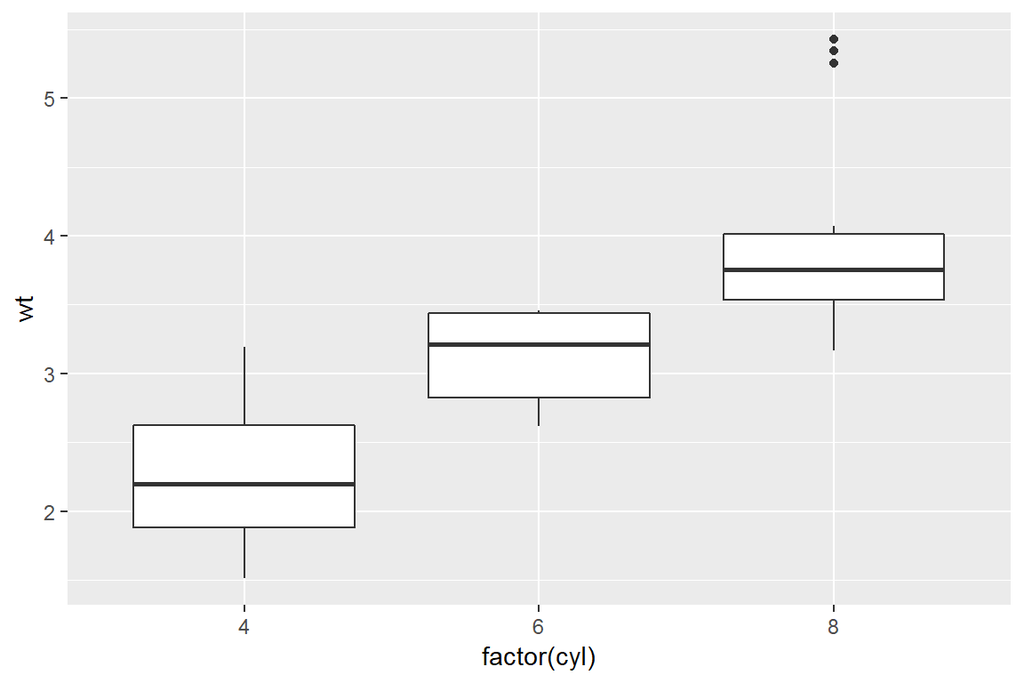

```r
ggplot(data=mtcars, mapping=aes(x=factor(cyl), y=wt)) + geom_boxplot()
```

**geom_smooth()**

我们可以使用geom_smooth()函数来添加一系列的平滑曲线和置信区域，其常用参数为：

| 参数 | 说明 |
| --- | --- |
| method | 使用的平滑函数。允许的值包括lm, glm, smooth, rlm和gam，分别表示线性、广义线性、loess、健壮线性和广义相加模型。默认值是smooth。 |
| formula | 在平滑函数中使用的公式。例如：`y~x`（默认）, `y~log(x)`, `y~poly(x, n)`表示n次多项式, `y~ns(x)`表示自由度为n的样条拟合； |
| se | 是否绘制置信区间。默认值为TRUE； |
| level | 置信区间的水平。默认值为95%； |
| fullrange | 拟合区是否应当涵盖全图。默认值为FALSE； |
| linetype | 线型 |
| size | 线的粗细 |
| color | 线的颜色 |
| fill | 填充区的颜色 |
| alpha | 色彩饱和度(alpha=0表示完全透明, alpha=1表示完全不透明) |

[output not shown]

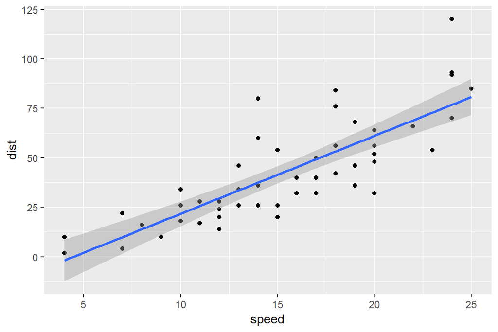

```r
ggplot(data=cars, mapping=aes(x=speed, y=dist))+geom_point()+geom_smooth(method="lm")
```

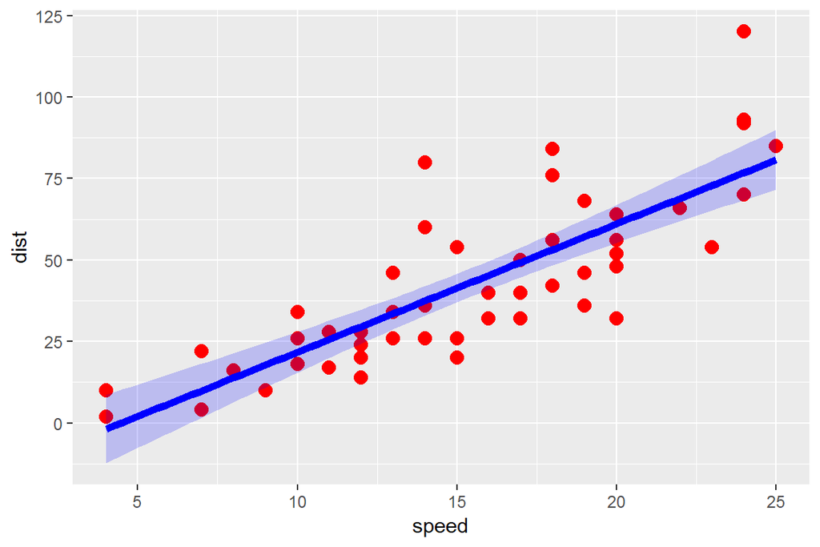

```r
ggplot(data=cars, mapping=aes(x=speed, y=dist)) +
  geom_point(pch=20, size=5, color="red") +
  geom_smooth(method="lm", linetype=1, size=2, color="blue", fill="blue", alpha=0.2)
```

使用formula参数，可以绘制多项式等曲线。例如：

> `method="lm", formula=y~poly(x,2)`

表示使用x的二次多项式来表示y，即拟合曲线为$y=a_0 + a_1 x + a_2 x^2$。

```r
myfit <- lm(dist ~ speed + I(speed^2), data=cars)
summary(myfit)
```

```
##
## Call:
## lm(formula = dist ~ speed + I(speed^2), data = cars)
##
## Residuals:
##     Min      1Q  Median      3Q     Max
## -28.720  -9.184  -3.188   4.628  45.152
##
## Coefficients:
##             Estimate Std. Error t value Pr(>|t|)
## (Intercept)  2.47014   14.81716   0.167    0.868
## speed        0.91329    2.03422   0.449    0.656
## I(speed^2)   0.09996    0.06597   1.515    0.136
##
## Residual standard error: 15.18 on 47 degrees of freedom
## Multiple R-squared:  0.6673, Adjusted R-squared:  0.6532
## F-statistic: 47.14 on 2 and 47 DF,  p-value: 5.852e-12
```

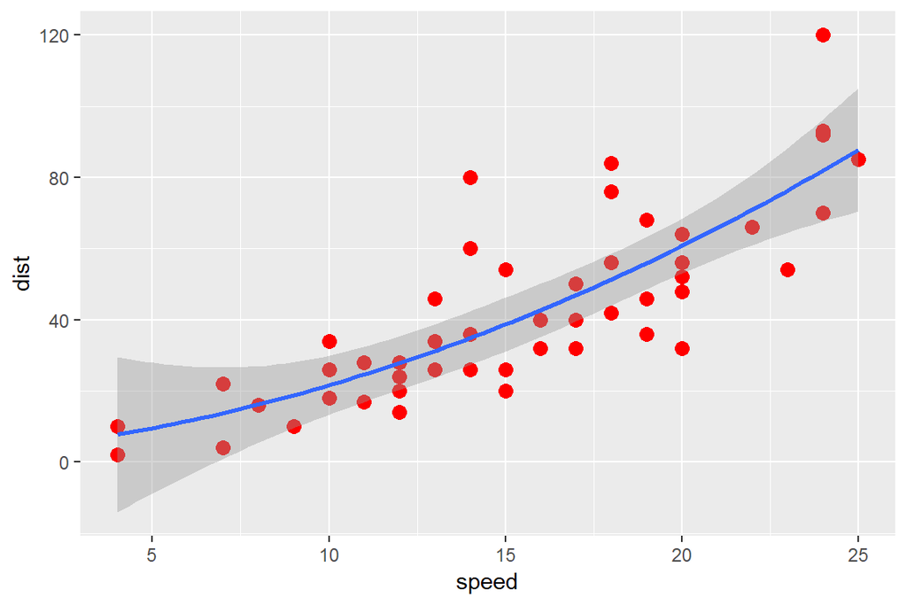

```r
ggplot(data=cars, mapping=aes(x=speed, y=dist)) +
  geom_point(size=3, color="red") +
  geom_smooth(method="lm", formula=y~poly(x, 2), level=0.99)
```

**geom_density()**

用于绘制密度图，功能与plot(density(x))相似。geom_density()只需要横坐标变量。

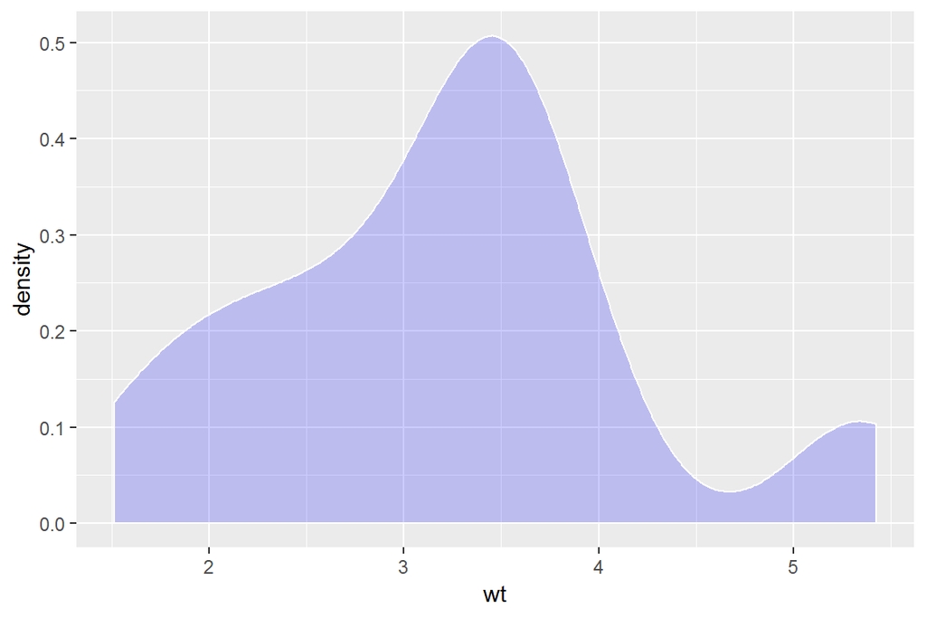

```r
ggplot(data=mtcars, mapping=aes(x=wt))+geom_density(fill="blue", alpha=0.2, color="white")
```

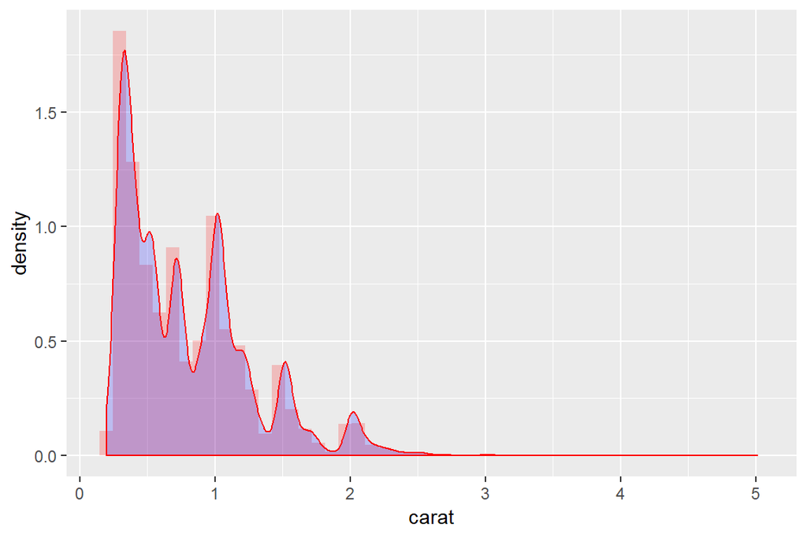

```r
#绘制概率密度直方图，再叠加上密度曲线
ggplot(data=diamonds, mapping=aes(x=carat, y=..density..))+
  geom_histogram(fill="red", alpha=0.2, bins=50)+
  geom_density(fill="blue", alpha=0.2, color="red")
```

**geom_count()**

用于绘制两个离散变量的各种组合出现的次数，用点的大小表示次数的多少。

```r
#统计每种切割质量、每种颜色的钻石的数量
table(diamonds$cut, diamonds$color)
```

```
##
##                D    E    F    G    H    I    J
##   Fair       163  224  312  314  303  175  119
##   Good       662  933  909  871  702  522  307
##   Very Good 1513 2400 2164 2299 1824 1204  678
##   Premium   1603 2337 2331 2924 2360 1428  808
##   Ideal     2834 3903 3826 4884 3115 2093  896
```

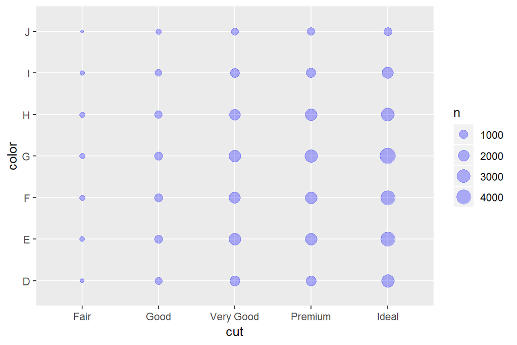

```r
#绘制成二维离散点图
ggplot(data=diamonds, mapping=aes(x=cut, y=color)) +
  geom_count(color="blue", alpha=0.3)
```

**geom_tile()**

geom_tile()的功能与geom_count()的功能类似，不同在于：geom_count()用点来表示每种组合，geom_tile()用色块来表示。

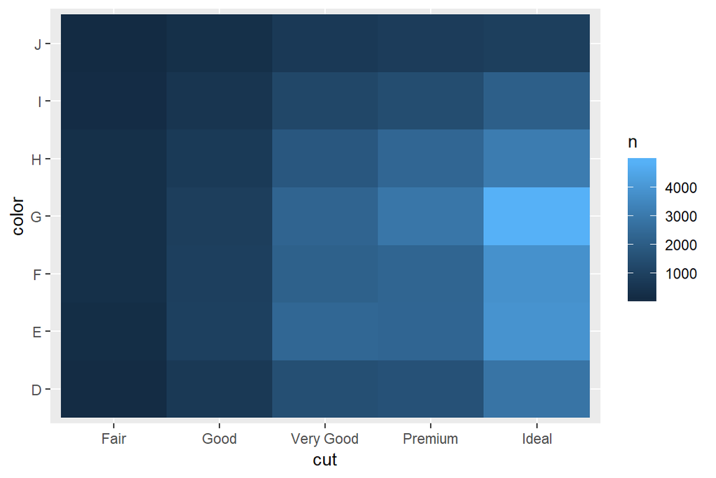

```r
diamonds %>%
  count(color, cut) %>%
  ggplot(mapping = aes(x = cut, y = color, fill=n)) +
  geom_tile()
```

最常用的几何函数：

- geom_point()
- geom_line()
- geom_bar()
- geom_histogram()
- geom_freqpoly()
- geom_boxplot()
- geom_smooth()
- geom_density()
- geom_count()
- geom_tile()

## 分组

在可视化时，通常需要先把数据分组，然后分别显示每组的情况。例如，对于mtcars数据集，根据汽缸数量(cyl)将汽车分组，观察每组汽车的重量分布情况。

在R中，组通常用因子来定义，因子的一个水平对应一个组。每个组在做图时用不同的颜色（或透明度）来表示。我们可以把几何函数的部分参数（如fill, color)放在mapping=aes()参数中，用因子作为它们的值，从而实现图形分组。

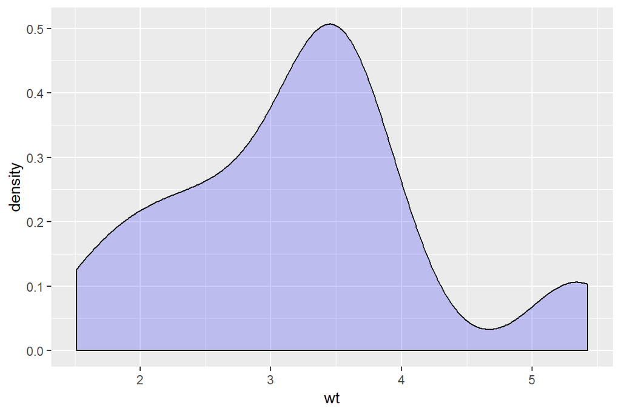

```r
#不分组，统一使用蓝色填充
ggplot(data=mtcars, mapping=aes(x=wt))+
  geom_density(fill="blue", alpha=0.2)
```

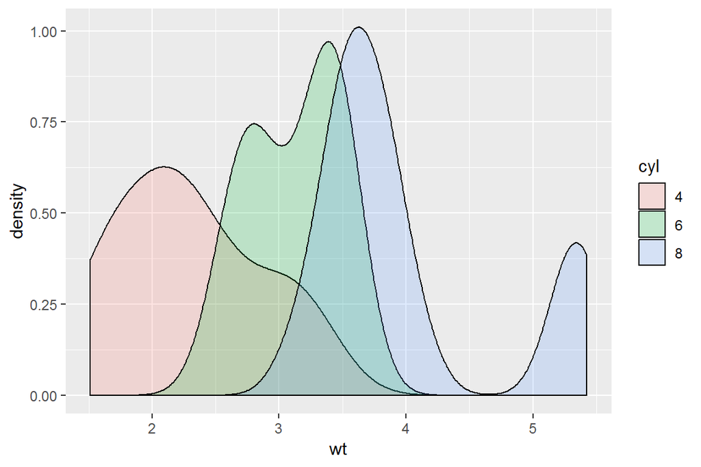

```r
#根据汽缸数，分组绘制汽车重量的密度图
mtcars$cyl <- factor(mtcars$cyl)  #先将cyl转换成因子
ggplot(data=mtcars, mapping=aes(x=wt, fill=cyl))+    #由cyl值决定每组的填充色
  geom_density(alpha=0.2)
```

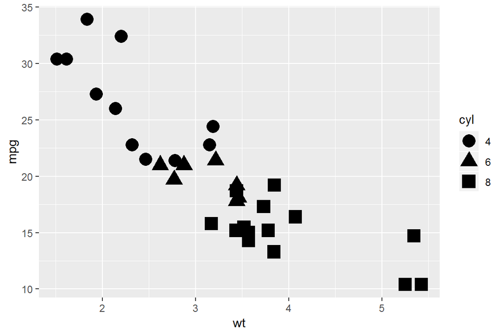

```r
#根据汽缸数，分组绘制车重-油耗关系图
ggplot(data=mtcars, mapping=aes(x=wt, y=mpg, shape=cyl))+geom_point(size=5)
```

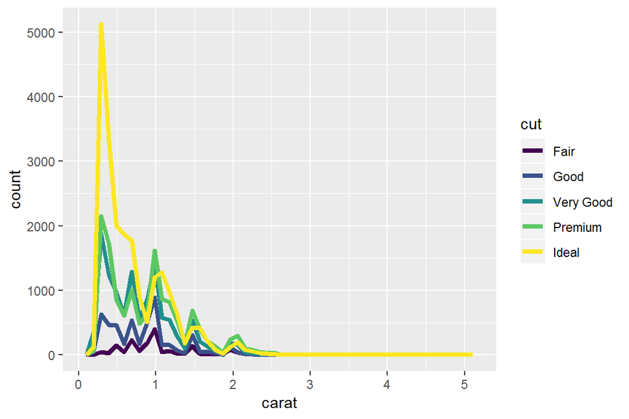

```r
#根据钻石的切割质量，分别绘制钻石的重量分布
ggplot(data=diamonds, mapping=aes(x=carat, color=cut))+geom_freqpoly(bins=50, size=1.5)
```

用因子为图形参数赋值，从而实现分组。根据这一原理，我们可以使用两个或更多因子进行多重分组。

取car包中的Salaries数据框，该数据框记载着大学老师的工资(salary)、性别(sex)、职级(rank)、博士毕业后的年数(yrs.since.phd)等信息。我们来分析sex、rank、yrs.since.phd对salary的影响。

```r
library(car)
```

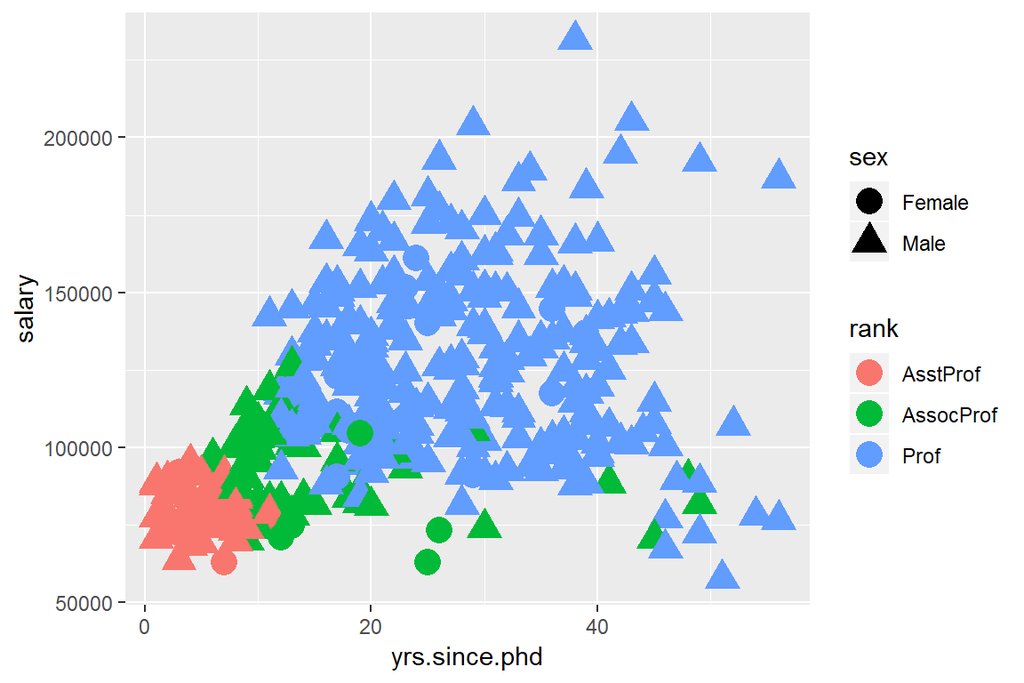

```r
ggplot(data=Salaries, mapping=aes(x=yrs.since.phd, y=salary, shape=sex, color=rank)) +
  geom_point(size=5)
```

**堆叠图**

对于条形图和直方图，如果存在多个分组，可以通过参数position来设置堆叠方式：

- position=“stack”，绘制堆叠图，是默认值；
- position=“dodge”，绘制并列图；
- position=“identity”，绘制覆盖图，即同组的多个条形会使用同一位置；

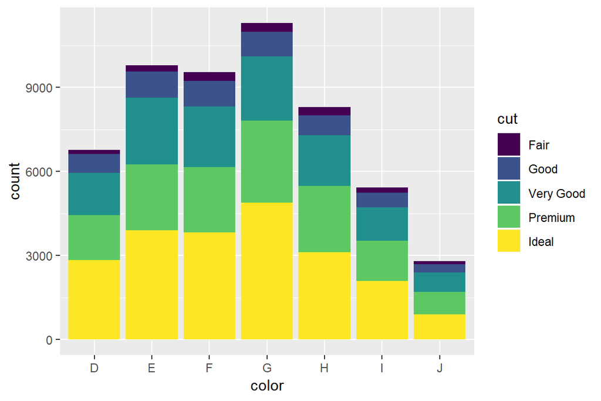

```r
ggplot(data=diamonds, mapping=aes(x=color, fill=cut)) + geom_bar()
```

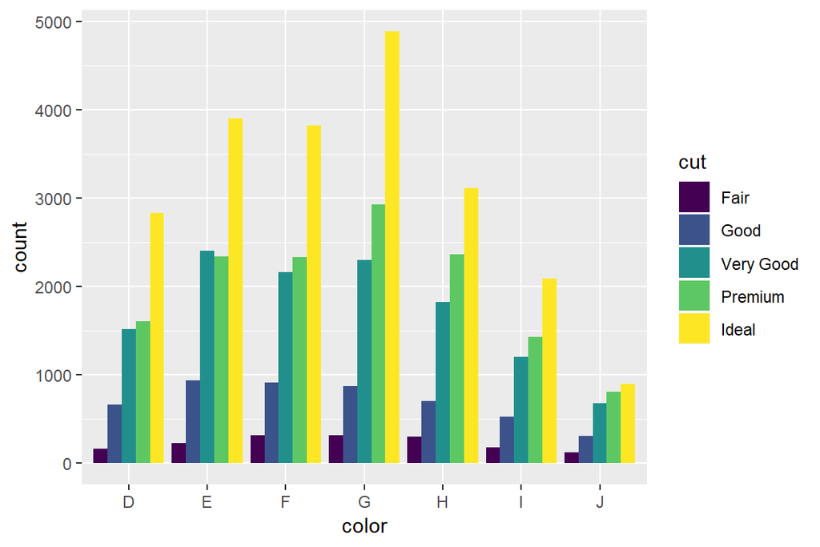

```r
ggplot(data=diamonds, mapping=aes(x=color, fill=cut)) +
  geom_bar(position="dodge")
```

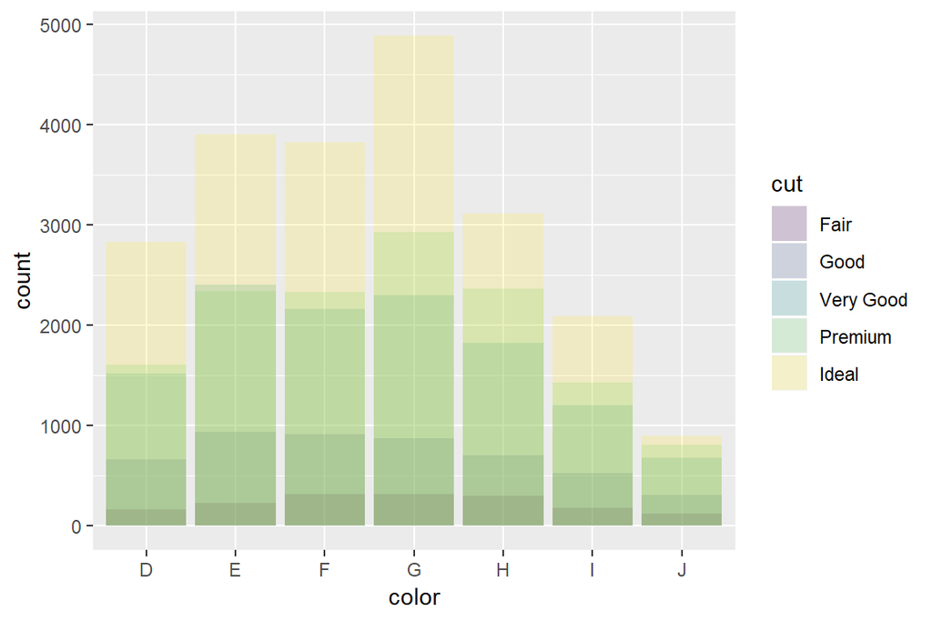

```r
ggplot(data=diamonds, mapping=aes(x=color, fill=cut)) +
  geom_bar(position="identity", alpha=0.2)
```

## Review

使用ggplot2绘图的一般方法是：

`ggplot() + geom_*()`+ 分面函数 + 修饰函数

## 分面

将若干幅图形排列成一个矩阵形式，称为分面(faceting)，这种矩阵图称为分面图。绘制分面图有两个函数：`facet_wrap()`和`facet_grid()`。注意：分面函数应放置在几何函数之后。

`facet_wrap()`可指定分面图的行数或列数：

facet_wrap(~var, nrow | ncol)

其中，`var`是一个因子变量，每个因子水平将绘制一幅图；nrow指定分面图的行数，ncol指定分面图的列数，二者选其一。

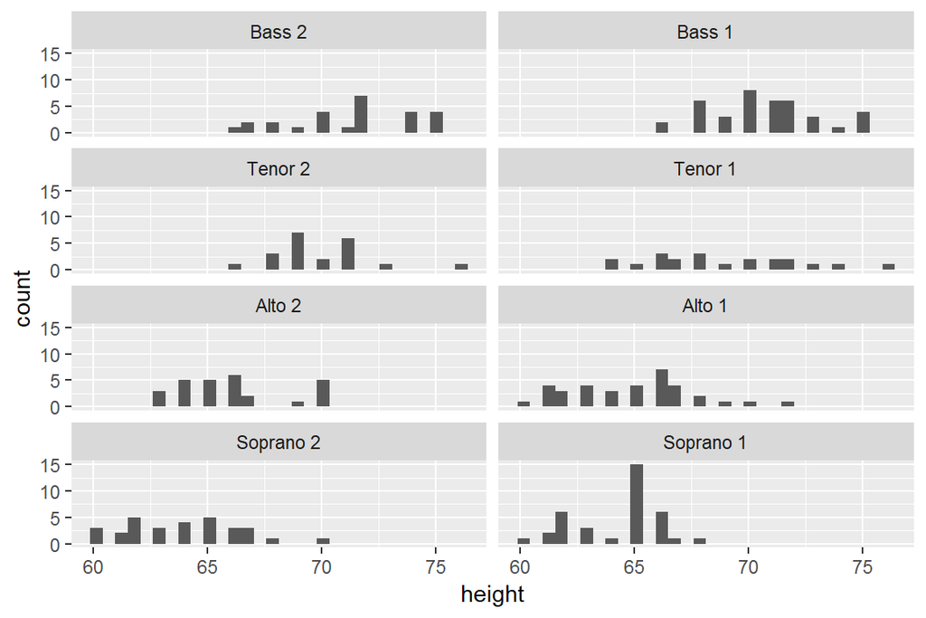

```r
library(lattice)

#显示每个声部的歌唱家的身高
ggplot(data=singer, mapping=aes(x=height)) +
  geom_histogram() + facet_wrap(~voice.part, nrow=4)
```

`facet_grid()`可绘制两个因子组成的分面图：

facet_grid(rowvar~colvar)

其中，rowvar决定行数，colvar决定列数，两个变量都必须是因子。若省略rowvar(即用.代替)，那么分面图就只有1行；若省略colvar(即用.代替)，那么分面图将只有1列。

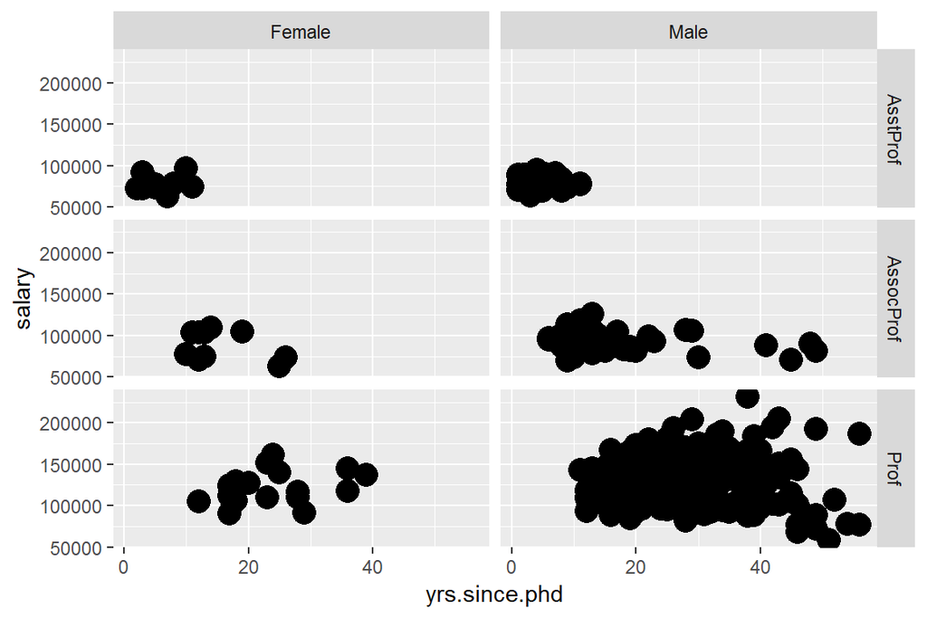

```r
library(car)
ggplot(data=Salaries, mapping=aes(x=yrs.since.phd, y=salary))+
  geom_point(size=5)+facet_grid(rank~sex)
```

## Review

使用ggplot2绘图的一般方法是：

`ggplot() + geom_*()`+ 分面函数 + 修饰函数

## 修饰函数

ggplot2提供了丰富的修饰函数，可修改坐标轴、图例、主题等。下面是最常用的几种修饰函数。

`labs()`可修改图名(title)、坐标轴名(x, y)。

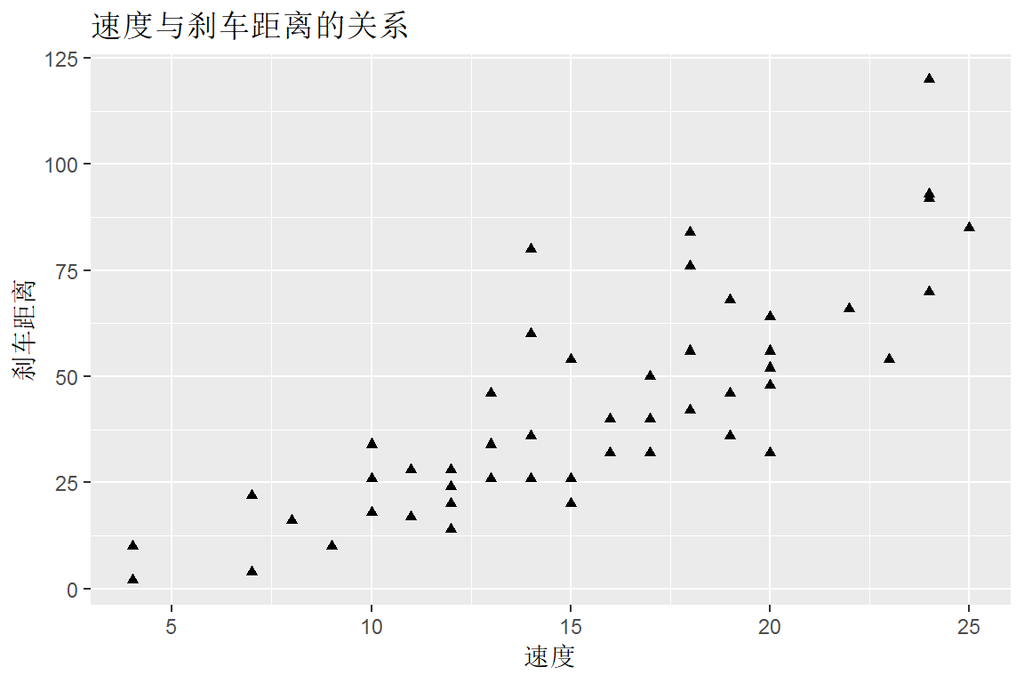

```r
ggplot(data=cars, mapping=aes(x=speed, y=dist))+geom_point(shape=17)+
  labs(title="速度与刹车距离的关系", x="速度", y="刹车距离")
```

另外，可使用`ggtitle()`、`xlab()`和`ylab()`分别修改图名、横坐标名和纵坐标名。

**坐标轴**

坐标轴有两种：一种是取连续值的坐标轴，用于表示数值向量；另一种是取离散值的坐标轴，用于表示因子。我们可以用两种函数分别改变这两种坐标轴上的刻度和标签。

scale_x_continuous(breaks, labels) scale_x_discrete(breaks, labels)

其中，breaks参数表示坐标轴上的刻度值，labels参数表示各刻度的标签；breaks和labels的值都是向量，并且应当等长。

对应地有`scale_y_continous()`和`scale_y_discrete()`函数，用于修改纵坐标的刻度和标签。

```r
library(car)
levels(Salaries$rank)
```

```
## [1] "AsstProf"  "AssocProf" "Prof"
```

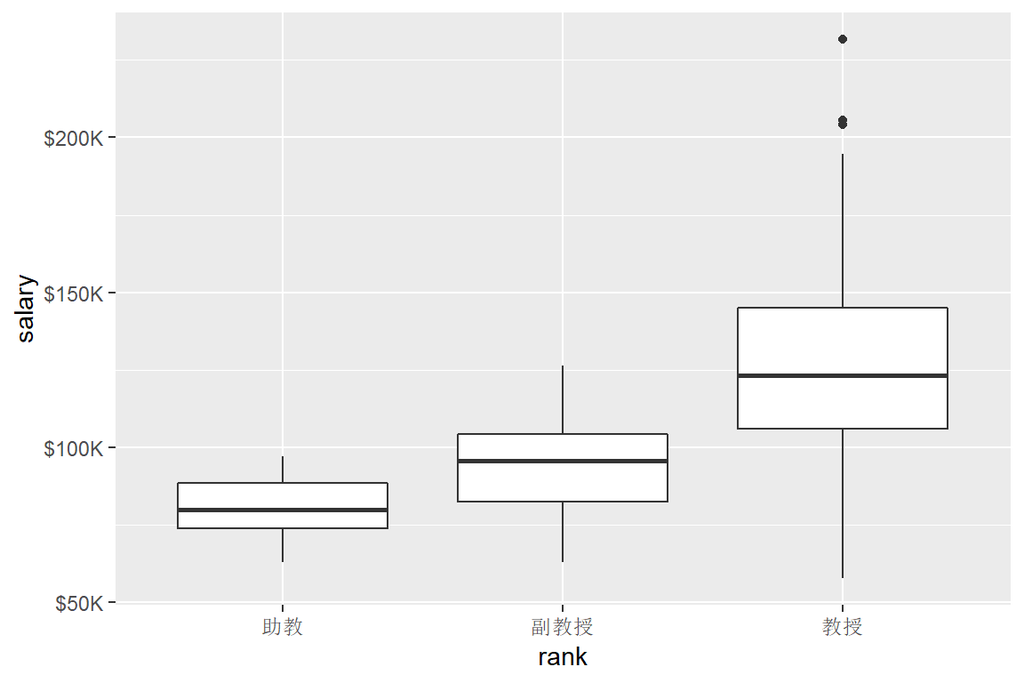

```r
ggplot(data=Salaries, mapping=aes(x=rank, y=salary)) + geom_boxplot() +
  scale_x_discrete(breaks=c("AsstProf", "AssocProf", "Prof"),
                   labels=c("助教", "副教授", "教授")) +
  scale_y_continuous(breaks=c(50000, 100000, 150000, 200000),
                     labels=c("$50K", "$100K", "$150K", "$200K"))
```

## Review

使用ggplot2绘图的一般方法是：

`ggplot() + geom_*()`+ 分面函数 + 修饰函数

DIY: gridExtra::grid.arrange()函数

## ggplot2进阶：图层

图层是ggplot2重要的概念。每个几何函数生成一个图层，多个几何函数生成的图层相互叠加可生成一幅复杂的图，这正是使用ggplot2绘图的一般方法。

实际上，每个几何函数都有参数data和mapping，用于设置绘图时的数据。如果没有为一个几何函数指定data和mapping，那么它使用ggplot()函数里面的参数值。例如：

> ggplot(data=cars, mapping=aes(x=speed, y=dist)) + geom_point()

等价于

> ggplot() + geom_point(data=cars, mapping=aes(x=speed, y=dist))

在进行分层绘图时，如果各个图层使用的data和mapping值不同，那么需要在各几何函数中分别指定这两个参数的值。

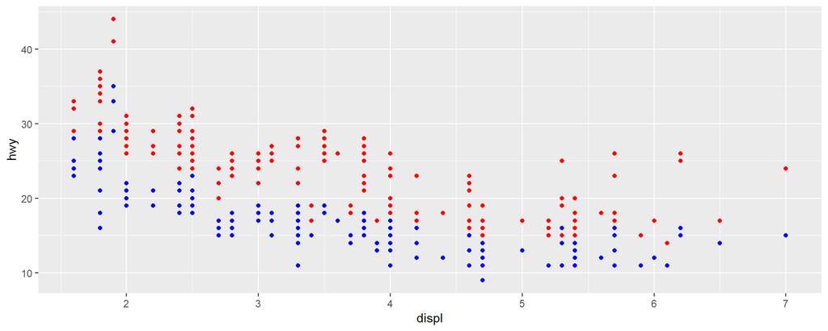

```r
#使用同一个数据集，但是两个图层使用的纵坐标变量不同
ggplot(data=mpg) +
  geom_point(mapping=aes(x=displ, y=hwy), color="red", na.rm=TRUE) +
  geom_point(mapping=aes(x=displ, y=cty), color="blue", na.rm=TRUE)
```

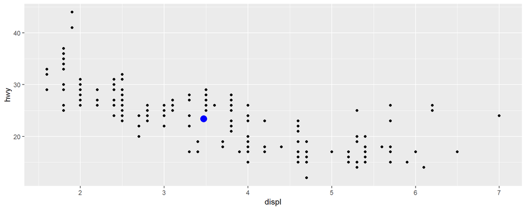

```r
#绘制所有的点，以及重心
#注意：可以在aes()中使用函数且可将列变量作为函数的参数
ggplot(data=mpg) +
  geom_point(mapping=aes(x=displ, y=hwy)) +
  geom_point(mapping=aes(x=mean(displ), y=mean(hwy)), color="blue", size=4)
```

错误的代码：

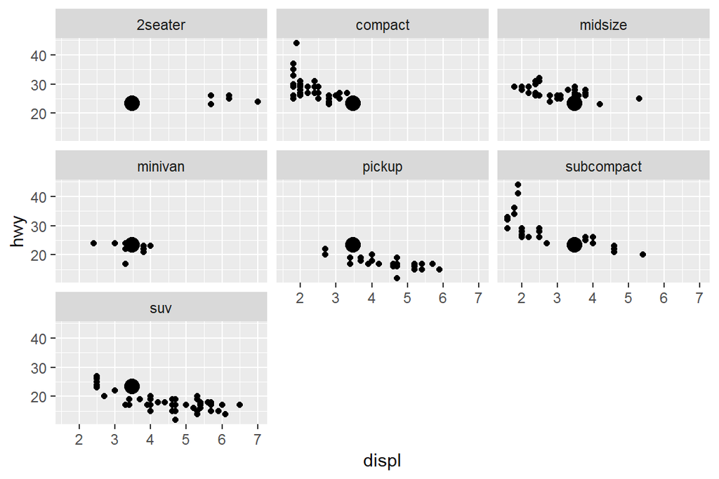

```r
#分别显示每类车辆的重心
ggplot(data=mpg) +
  geom_point(mapping=aes(x=displ, y=hwy)) +
  geom_point(mapping=aes(x=mean(displ), y=mean(hwy)), size=4) +
  facet_wrap(~class)
```

对`facet_wrap()`的理解：先完整地绘制各个图层，之后facet_wrap()将各图层上的点挑选出来分成多个小图。上面的代码错误在于：误认为先分成各个小图，再绘制各个图层。

更多的例子：

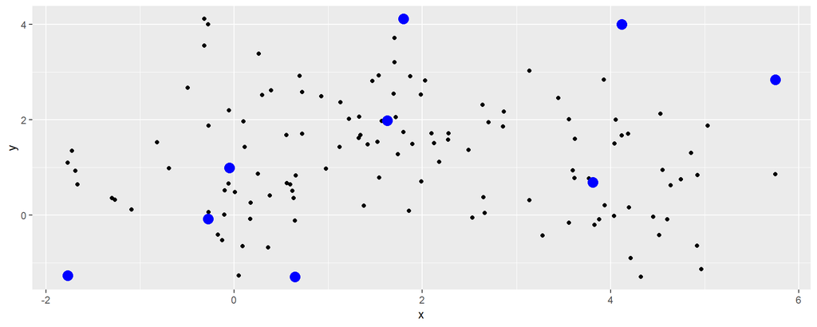

```r
#生成3类随机点
#a类点的坐标：x~N(0, 1), y~N(1, 1)
#b类点的坐标：x~N(2, 1), y~N(2, 1)
#c类点的坐标：x~N(4, 1), y~N(1, 1)
#每类随机点各有40个
df <- data.frame(
  x=rnorm(120, mean=c(0, 2, 4)),
  y=rnorm(120, mean=c(1, 2, 1)),
  z=letters[1:3]
)

#计算出每类点的重心坐标、最小坐标、最大坐标
df_stat <- rbind(
  aggregate(df[c("x", "y")], by=list(z=df$z), FUN=mean),
  aggregate(df[c("x", "y")], by=list(z=df$z), FUN=min),
  aggregate(df[c("x", "y")], by=list(z=df$z), FUN=max) )

#生成两个图层，每个图层使用不同的数据
ggplot()+
  geom_point(data=df, mapping=aes(x=x, y=y))+
  geom_point(data=df_stat, mapping=aes(x=x, y=y), color="blue", size=4)
```

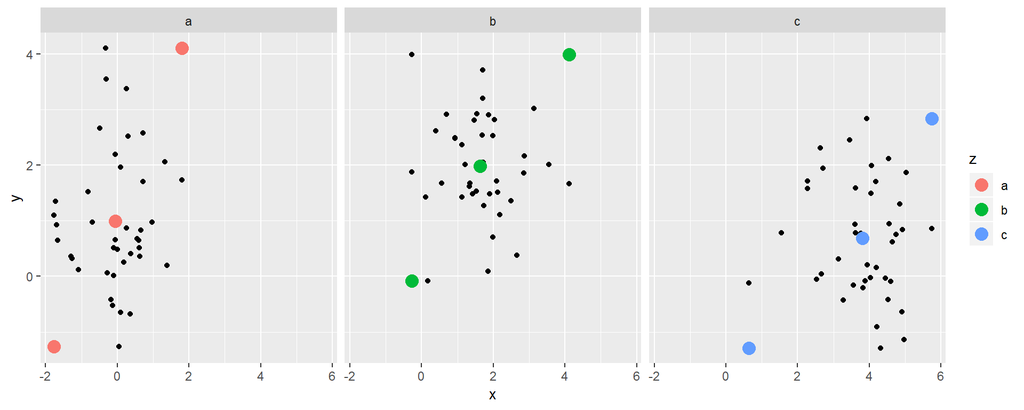

```r
#同时有分组和分面
ggplot() +
  geom_point(data=df, mapping=aes(x=x, y=y)) +
  geom_point(data=df_stat, mapping=aes(x=x, y=y, color=z), size=4) +
  facet_wrap(~z)
```

在绘制图层时，允许直接使用向量绘图，此时需要设置`data=NULL`。

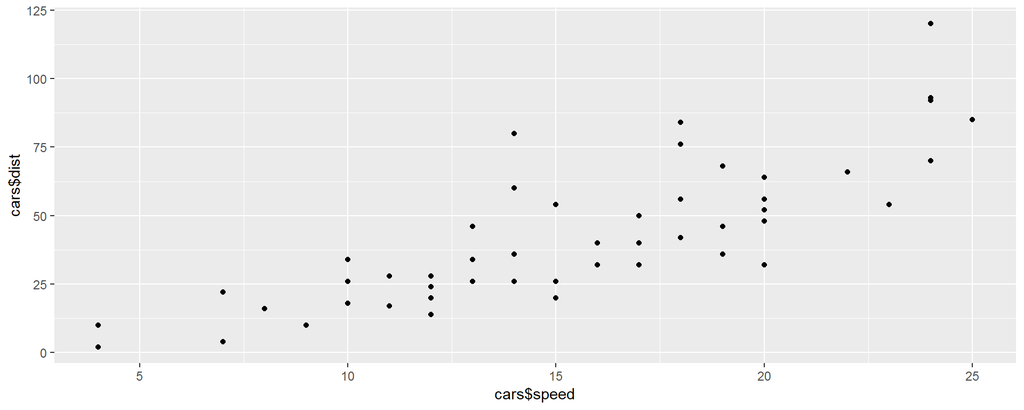

```r
#直接使用两个向量作为x轴和y轴
ggplot(data=NULL, mapping=aes(x=cars$speed, y=cars$dist)) + geom_point()
```